# Exploring Social Metacognition - Advisor/Cue comparison

Matt Jaquiery (matt.jaquiery@psy.ox.ac.uk)

December 2018  
[Script run 2019-01-08 15:40:09]

# Descriptives

## Introduction

Participants performed a perceptual discrimination task in a judge-advisor system. Participants were randomly assigned to receive advice either from ‘Advisors’ or ‘Cues’. The two advisor classes are tested for differences, particularly in pick rates and influence within pairs of advisors which differ in the frequency with which their advice agrees with the participant’s initial decision.

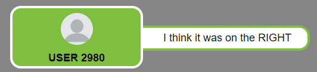

Advisor advice

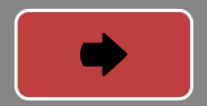

Cue advice

## Load data

```
## [1] "##--- Simulating Advisor Choice data ---##"
## [1] "Simulating 1920 trials from 16 participants."
## [1] "##--- Completed in 11.48s ---##"
```

```
## Loaded data from ESM_sim.R
```

```
## Generated utility variables
```

## Describe data

### Metadata

Responses (*N* = 16) were collected between 2019-01-08 15:40:12 and 2019-01-08 15:40:23.

Demographic data are not collected and therefore not analysed. Participants must be over 18 years old to use the Prolific recruitment platform.

### Task performance

#### Type 1 performance

Participants initial performance was held at 71% by design. Participants’ mean percentage correct on initial decisions was *M* = .70 [0.68, 0.72]. We would expect final decisions to be more accurate due to the presence of advice:

*t*(15) = -0.64, *p* = .533, *d* = .14, BF = 0.31; *M*|initial = .70 [0.68, 0.72], *M*|final = .70 [0.68, 0.72]

Type 1 performance should not differ in initial decisions as a function of advisor class (Advisor vs Cue). The final decisions might differ if advice taking differs between the advisor classes.

Initial decisions:

*t*(13.74) = -0.36, *p* = .724, *d* = .18, BF = 0.45; *M*|Advisor = .69 [0.66, 0.72], *M*|Cue = .70 [0.66, 0.74]

Final decisions:

*t*(13.93) = -0.05, *p* = .957, *d* = .03, BF = 0.43; *M*|Advisor = .70 [0.67, 0.73], *M*|Cue = .70 [0.67, 0.73]

#### Type 2 performance

Type 2 (metacognitive) performance is characterised using Type 2 ROC. The mean ROC for all participants is tabulated below:

| conf | decision | pCorrect |
| --- | --- | --- |
| (0,8.33] | initial | .50 |
| (8.33,16.7] | initial | .46 |
| (16.7,25] | initial | .46 |
| (25,33.3] | initial | .77 |
| (33.3,41.7] | initial | .84 |
| (41.7,50] | initial | .75 |
| (0,8.33] | final | .49 |
| (8.33,16.7] | final | .64 |
| (16.7,25] | final | .63 |
| (25,33.3] | final | .68 |
| (33.3,41.7] | final | .73 |
| (41.7,50] | final | .77 |

Participants’ ROC curves:

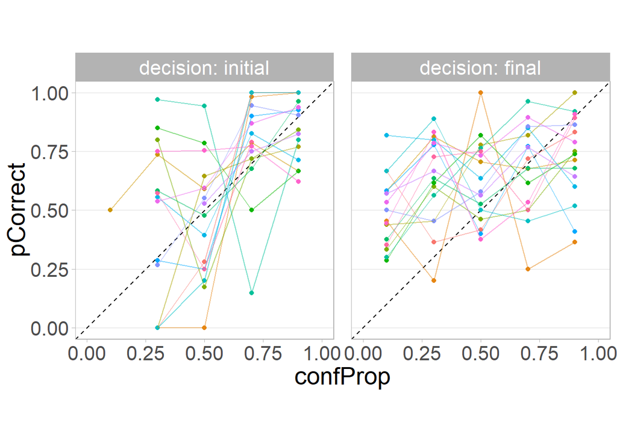

### Exclusions

We exclude participants for:

- Proportion of correct initial judgements must be (.60 < cor1/n < .90) (*N* = 0)
- Having fewer than 3 confidence categories (*N* = 0)
- Having fewer than 5% of trials in each confidence category (*N* = 0)
- There being more data collected than specified in pre-registration (*N* = 0)

*NB: **practice trials are included** in this since they are used in part for determining confidence calibration*

The number of participants analysed after exclusions (total *N* = 0) have taken place is 16.

### Advisor performance

#### Manipulation checks

The advisors need to differ appropriately. How they differ depends on the advisors being compared, but in each case we need to check the participants’ experience of the advisors matched the specifications for the advisors.

|  | mean | sd | ciLow | ciHigh | rangeLow | rangeHigh |
| --- | --- | --- | --- | --- | --- | --- |
| HighAgrAgrees | .764 | .046 | .739 | .788 | .617 | .817 |
| LowAgrAgrees | .515 | .051 | .487 | .542 | .417 | .600 |

*t*(15) = 13.91, *p* < .001, *d* = 5.09, BF = 16777137.91; *M*|HighAgrAgrees = .76 [0.74, 0.79], *M*|LowAgrAgrees = .51 [0.49, 0.54]

This experience should not differ by advisor class for either advice type:

BF = 0.59; *M*|HighAgrAgrees|Advisor = .75 [0.70, 0.80], *M*|HighAgrAgrees|Cue = .78 [0.75, 0.80]

BF = 0.59; *M*|LowAgrAgrees|Advisor = .53 [0.49, 0.57], *M*|LowAgrAgrees|Cue = .50 [0.46, 0.55]

#### Initial decision comparability

The participants’ initial decisions should be equivalent (BF < .333) between advisors. Comparing initial decision by advice profile we can see whether this was the case:

BF = 0.88; *M*|HighAgr = .68 [0.62, 0.73], *M*|LowAgr = .73 [0.69, 0.77]

# Pick rate differences

The primary outcome is the relative frequencies of advisor picking on trials where there is a choice of advisor. Choices occur on *change* trials which provide a default advisor and allow the participant to hear advice from the other advisor instead by pressing a key within a selection window (1500ms). Critically, the proportion of trials on which each advisor is the default is balanced.

## Change trials

Change trials are analysed in two ways. First, by inspecting whether the proportion of trials on which advice was received from the reference advisor differs by advisor class:

*t*(12.73) = -1.58, *p* = .138, *d* = .79, BF = 0.96; *P*(HighAgr|Advisor) = .52 [0.38, 0.67], *P*(HighAgr|Cue) = .64 [0.54, 0.75]

Second, by comparing the proportion of changes which favoured the reference advisor by advisor class:

*t*(12.91) = -1.02, *p* = .327, *d* = .51, BF = 0.60; *P*(HighAgr|Advisor) = .53 [0.38, 0.68], *P*(HighAgr|Cue) = .61 [0.50, 0.72]

Graph for advice received:

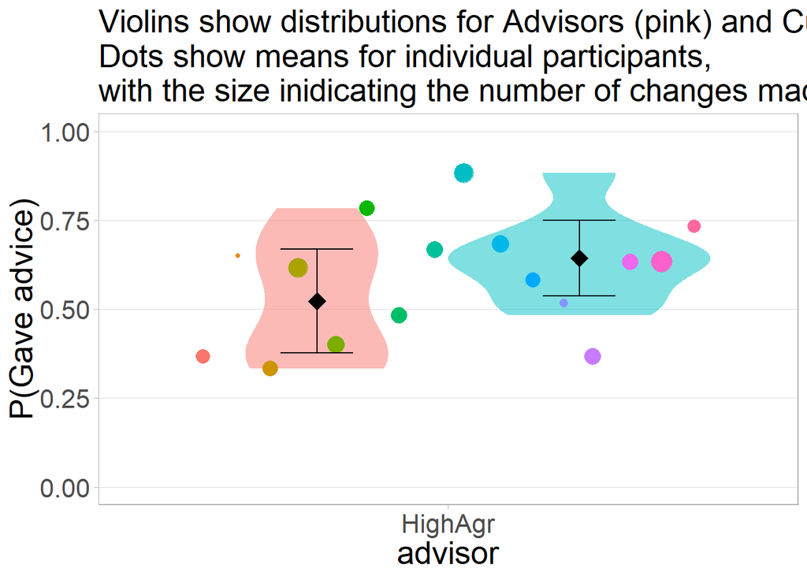

Graph for the changes only:

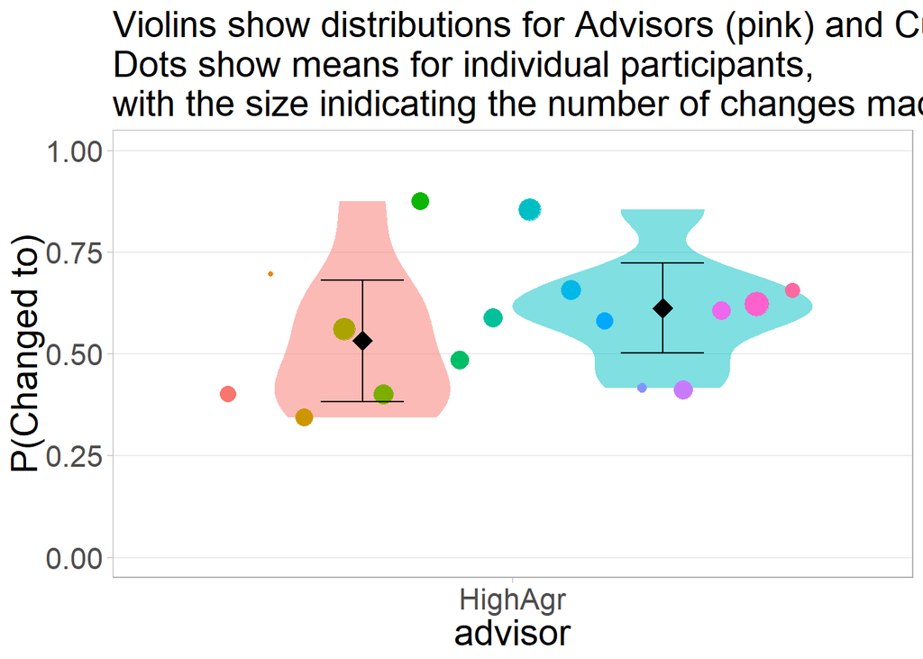

For completeness we also check the proportion of trials on which the reference advisor is the default advisor is equivalent to .5.

BF = 0.26; HighAgr = .50 [0.47, 0.53], $\mu$ = 0.5

# Influence differences

Influence, defined as the extent to which a participant adjusts their answer in the direction of an advisor’s advice, can be compared between advisors. Note that the experimental design is not optimised for measuring this outcome because influence may vary systematically with choices, and the trials without choices constitute a learning phase wherein preferences cannot be expected to have crystalised.

For dual trials the confidence shift is modelled using a linear model in which the initial confidence and the agreement of each advisor (and their interaction) are used as predictors:

```
## [1] "LM results for High agreement vs Low agreement"
##
## Call:
## lm(formula = f, data = df)
##
## Residuals:
##     Min      1Q  Median      3Q     Max
## -29.357  -4.263   0.264   4.735  29.836
##
## Coefficients:
##                                                       Estimate Std. Error
## (Intercept)                                          -10.88239    1.29572
## pid                                                   -0.08756    0.05696
## initialConfidence                                     -0.12242    0.03277
## HighAgr_agreesTRUE                                    33.00944    1.13444
## LowAgr_agreesTRUE                                     -3.57922    1.41550
## advisorClassCue                                        3.03210    1.38298
## HighAgr_agreesTRUE:LowAgr_agreesTRUE                  -2.32575    1.62969
## HighAgr_agreesTRUE:advisorClassCue                    -1.57024    1.60936
## LowAgr_agreesTRUE:advisorClassCue                     -3.27304    2.05576
## HighAgr_agreesTRUE:LowAgr_agreesTRUE:advisorClassCue  -0.86983    2.35056
##                                                      t value Pr(>|t|)
## (Intercept)                                           -8.399  < 2e-16 ***
## pid                                                   -1.537 0.124563
## initialConfidence                                     -3.736 0.000198 ***
## HighAgr_agreesTRUE                                    29.098  < 2e-16 ***
## LowAgr_agreesTRUE                                     -2.529 0.011613 *
## advisorClassCue                                        2.192 0.028590 *
## HighAgr_agreesTRUE:LowAgr_agreesTRUE                  -1.427 0.153877
## HighAgr_agreesTRUE:advisorClassCue                    -0.976 0.329466
## LowAgr_agreesTRUE:advisorClassCue                     -1.592 0.111687
## HighAgr_agreesTRUE:LowAgr_agreesTRUE:advisorClassCue  -0.370 0.711426
## ---
## Signif. codes:  0 '***' 0.001 '**' 0.01 '*' 0.05 '.' 0.1 ' ' 1
##
## Residual standard error: 7.683 on 950 degrees of freedom
## Multiple R-squared:  0.756,  Adjusted R-squared:  0.7536
## F-statistic:   327 on 9 and 950 DF,  p-value: < 2.2e-16
```

# Credits

## Acknowledgements

Thanks as always to Nick Yeung and the other folks at the [ACC Lab](https://www.psy.ox.ac.uk/research/attention-cognitive-control-lab).

## R Packages

| Package | Citations |
| --- | --- |
| base | R Core Team (2018). R: A language and environment for statistical computing. R Foundation for Statistical Computing, Vienna, Austria. URL https://www.R-project.org/. |
| Rcpp | Dirk Eddelbuettel and Romain Francois (2011). Rcpp: Seamless R and C++ Integration. Journal of Statistical Software, 40(8), 1-18. URL http://www.jstatsoft.org/v40/i08/. Eddelbuettel, Dirk (2013) Seaml… |
| prettyMD | Matt Jaquiery (2018). prettyMD: Format Test Outputs with Markdown. R package version 0.1.0. |
| scoring | Merkle, E. C. & Steyvers, M. (2013). Choosing a strictly proper scoring rule. Decision Analysis, 10, 292-304. |
| Hmisc | Frank E Harrell Jr, with contributions from Charles Dupont and many others. (2018). Hmisc: Harrell Miscellaneous. R package version 4.1-1. https://CRAN.R-project.org/package=Hmisc |
| Formula | Achim Zeileis, Yves Croissant (2010). Extended Model Formulas in R: Multiple Parts and Multiple Responses. Journal of Statistical Software 34(1), 1-13. doi:10.18637/jss.v034.i01 |
| survival |  |
| lattice | Sarkar, Deepayan (2008) Lattice: Multivariate Data Visualization with R. Springer, New York. ISBN 978-0-387-75968-5 |
| knitr | Yihui Xie (2018). knitr: A General-Purpose Package for Dynamic Report Generation in R. R package version 1.20. Yihui Xie (2015) Dynamic Documents with R and knitr. 2nd edition. Chapman and Hall/CRC. I… |
| ez | Michael A. Lawrence (2016). ez: Easy Analysis and Visualization of Factorial Experiments. R package version 4.4-0. https://CRAN.R-project.org/package=ez |
| lsr | Navarro, D. J. (2015) Learning statistics with R: A tutorial for psychology students and other beginners. (Version 0.5) University of Adelaide. Adelaide, Australia |
| lme4 | Douglas Bates, Martin Maechler, Ben Bolker, Steve Walker (2015). Fitting Linear Mixed-Effects Models Using lme4. Journal of Statistical Software, 67(1), 1-48. doi:10.18637/jss.v067.i01. |
| ggridges | Claus O. Wilke (2018). ggridges: Ridgeline Plots in ‘ggplot2’. R package version 0.5.1. https://CRAN.R-project.org/package=ggridges |
| forcats | Hadley Wickham (2018). forcats: Tools for Working with Categorical Variables (Factors). R package version 0.3.0. https://CRAN.R-project.org/package=forcats |
| stringr | Hadley Wickham (2018). stringr: Simple, Consistent Wrappers for Common String Operations. R package version 1.3.1. https://CRAN.R-project.org/package=stringr |
| dplyr | Hadley Wickham, Romain François, Lionel Henry and Kirill Müller (2018). dplyr: A Grammar of Data Manipulation. R package version 0.7.6. https://CRAN.R-project.org/package=dplyr |
| purrr | Lionel Henry and Hadley Wickham (2018). purrr: Functional Programming Tools. R package version 0.2.5. https://CRAN.R-project.org/package=purrr |
| readr | Hadley Wickham, Jim Hester and Romain Francois (2017). readr: Read Rectangular Text Data. R package version 1.1.1. https://CRAN.R-project.org/package=readr |
| tidyr | Hadley Wickham and Lionel Henry (2018). tidyr: Easily Tidy Data with ‘spread()’ and ‘gather()’ Functions. R package version 0.8.1. https://CRAN.R-project.org/package=tidyr |
| tibble | Kirill Müller and Hadley Wickham (2018). tibble: Simple Data Frames. R package version 1.4.2. https://CRAN.R-project.org/package=tibble |
| ggplot2 | H. Wickham. ggplot2: Elegant Graphics for Data Analysis. Springer-Verlag New York, 2016. |
| tidyverse | Hadley Wickham (2017). tidyverse: Easily Install and Load the ‘Tidyverse’. R package version 1.2.1. https://CRAN.R-project.org/package=tidyverse |
| BayesFactor | Richard D. Morey and Jeffrey N. Rouder (2018). BayesFactor: Computation of Bayes Factors for Common Designs. R package version 0.9.12-4.2. https://CRAN.R-project.org/package=BayesFactor |
| Matrix | Douglas Bates and Martin Maechler (2018). Matrix: Sparse and Dense Matrix Classes and Methods. R package version 1.2-14. https://CRAN.R-project.org/package=Matrix |
| coda | Martyn Plummer, Nicky Best, Kate Cowles and Karen Vines (2006). CODA: Convergence Diagnosis and Output Analysis for MCMC, R News, vol 6, 7-11 |
| jsonlite | Jeroen Ooms (2014). The jsonlite Package: A Practical and Consistent Mapping Between JSON Data and R Objects. arXiv:1403.2805 [stat.CO] URL https://arxiv.org/abs/1403.2805. |

## Funding

Matt Jaquiery is funded by a studentship from the [Medical Research Council](https://mrc.ukri.org/) (reference 1943590) and the University of Oxford [Department of Experimental Psychology](https://www.psy.ox.ac.uk/) (reference 17/18_MSD_661552).